# White Wine Quality by Kutay Erkan

In this report, we will try to explore a dataset with approximately 4900 observations about the attributes of white wine and its perceived quality.

# Univariate Plots Section

In our dataset, we have 4898 observations and 13 columns.

```
## 'data.frame':    4898 obs. of  13 variables:
##  $ X                   : int  1 2 3 4 5 6 7 8 9 10 ...
##  $ fixed.acidity       : num  7 6.3 8.1 7.2 7.2 8.1 6.2 7 6.3 8.1 ...
##  $ volatile.acidity    : num  0.27 0.3 0.28 0.23 0.23 0.28 0.32 0.27 0.3 0.22 ...
##  $ citric.acid         : num  0.36 0.34 0.4 0.32 0.32 0.4 0.16 0.36 0.34 0.43 ...
##  $ residual.sugar      : num  20.7 1.6 6.9 8.5 8.5 6.9 7 20.7 1.6 1.5 ...
##  $ chlorides           : num  0.045 0.049 0.05 0.058 0.058 0.05 0.045 0.045 0.049 0.044 ...
##  $ free.sulfur.dioxide : num  45 14 30 47 47 30 30 45 14 28 ...
##  $ total.sulfur.dioxide: num  170 132 97 186 186 97 136 170 132 129 ...
##  $ density             : num  1.001 0.994 0.995 0.996 0.996 ...
##  $ pH                  : num  3 3.3 3.26 3.19 3.19 3.26 3.18 3 3.3 3.22 ...
##  $ sulphates           : num  0.45 0.49 0.44 0.4 0.4 0.44 0.47 0.45 0.49 0.45 ...
##  $ alcohol             : num  8.8 9.5 10.1 9.9 9.9 10.1 9.6 8.8 9.5 11 ...
##  $ quality             : int  6 6 6 6 6 6 6 6 6 6 ...
```

```
##        X        fixed.acidity    volatile.acidity  citric.acid
##  Min.   :   1   Min.   : 3.800   Min.   :0.0800   Min.   :0.0000
##  1st Qu.:1225   1st Qu.: 6.300   1st Qu.:0.2100   1st Qu.:0.2700
##  Median :2450   Median : 6.800   Median :0.2600   Median :0.3200
##  Mean   :2450   Mean   : 6.855   Mean   :0.2782   Mean   :0.3342
##  3rd Qu.:3674   3rd Qu.: 7.300   3rd Qu.:0.3200   3rd Qu.:0.3900
##  Max.   :4898   Max.   :14.200   Max.   :1.1000   Max.   :1.6600
##  residual.sugar     chlorides       free.sulfur.dioxide
##  Min.   : 0.600   Min.   :0.00900   Min.   :  2.00
##  1st Qu.: 1.700   1st Qu.:0.03600   1st Qu.: 23.00
##  Median : 5.200   Median :0.04300   Median : 34.00
##  Mean   : 6.391   Mean   :0.04577   Mean   : 35.31
##  3rd Qu.: 9.900   3rd Qu.:0.05000   3rd Qu.: 46.00
##  Max.   :65.800   Max.   :0.34600   Max.   :289.00
##  total.sulfur.dioxide    density             pH          sulphates
##  Min.   :  9.0        Min.   :0.9871   Min.   :2.720   Min.   :0.2200
##  1st Qu.:108.0        1st Qu.:0.9917   1st Qu.:3.090   1st Qu.:0.4100
##  Median :134.0        Median :0.9937   Median :3.180   Median :0.4700
##  Mean   :138.4        Mean   :0.9940   Mean   :3.188   Mean   :0.4898
##  3rd Qu.:167.0        3rd Qu.:0.9961   3rd Qu.:3.280   3rd Qu.:0.5500
##  Max.   :440.0        Max.   :1.0390   Max.   :3.820   Max.   :1.0800
##     alcohol         quality
##  Min.   : 8.00   Min.   :3.000
##  1st Qu.: 9.50   1st Qu.:5.000
##  Median :10.40   Median :6.000
##  Mean   :10.51   Mean   :5.878
##  3rd Qu.:11.40   3rd Qu.:6.000
##  Max.   :14.20   Max.   :9.000
```

Our initial observations are:

- There are 4898 observations and 13 variables.
- Quality and X are integer variables.
- Quality is the variable we will focus on the most. It is an integer (discrete) and categorical variable with values between 3 and 9. Its mean is 5.878 and median is 6.
- X seems to be a numerical Unique Identifier Variable, as difference between consecutive variables is always 1.

```r
all(diff(raw$x) == 1)
```

```
## [1] TRUE
```

we also check to see if there are any non-positive values in our dataframe:

```r
colSums(raw == 0)
```

```
##                    X        fixed.acidity     volatile.acidity
##                    0                    0                    0
##          citric.acid       residual.sugar            chlorides
##                   19                    0                    0
##  free.sulfur.dioxide total.sulfur.dioxide              density
##                    0                    0                    0
##                   pH            sulphates              alcohol
##                    0                    0                    0
##              quality
##                    0
```

```r
colSums(raw < 0)
```

```
##                    X        fixed.acidity     volatile.acidity
##                    0                    0                    0
##          citric.acid       residual.sugar            chlorides
##                    0                    0                    0
##  free.sulfur.dioxide total.sulfur.dioxide              density
##                    0                    0                    0
##                   pH            sulphates              alcohol
##                    0                    0                    0
##              quality
##                    0
```

We see that only citric.acid contains 19 zero values. It is curious if this is because it is not reported or those observations really contained zero values, and we will keep this in mind.

We will draw quick histograms for all variables to get a general idea of the variables, using X as the unique id. We’ll free the x axis so that histograms of different variables become meaningful.

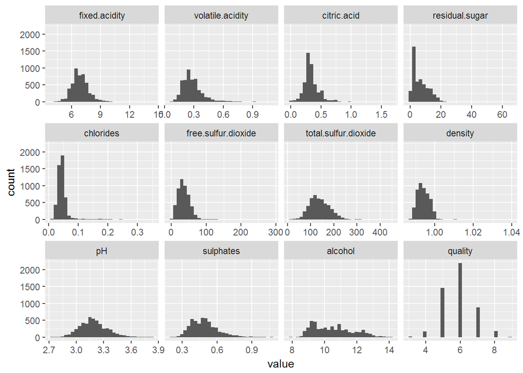

From now on we don’t need X as a unique id in the melted histograms above, so we can set it to NULL.

```r
raw$X = NULL
```

We also see that as quality is a discrete variable, it can be better shown is the following way with geom_bar (we once again see that minimum quality is 3 and maximum is 9):

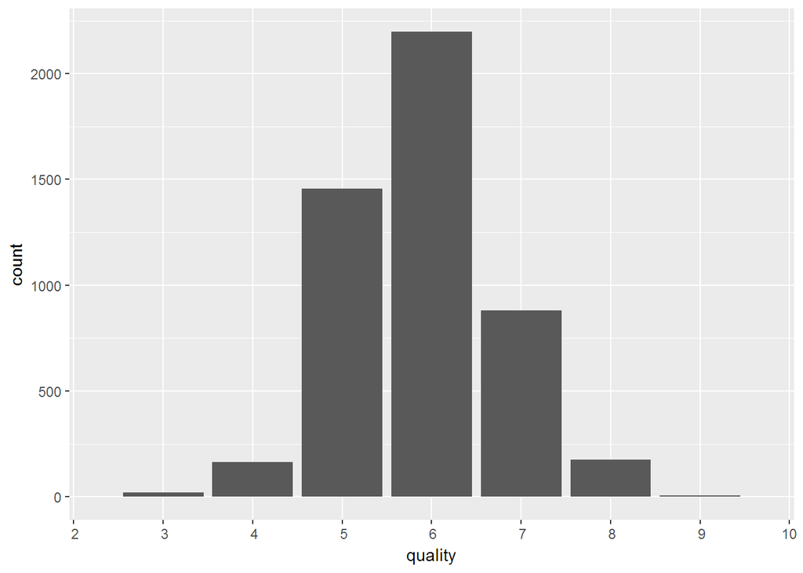

# Univariate Analysis

### Transformations

When we look at our histograms, we see that following variables seem skewed: * fixed.acidity * volatile.acidity * citric.acid * free.sulfur.dioxide * total.sulfur.dioxide * sulphates * alcohol

When we research it, we learn that pH scale is approximately base 10 logarithm of hydrogen ions in a solution. Considering this fact and the tails, we will transform *.acidity variables using base 10 logarithm.

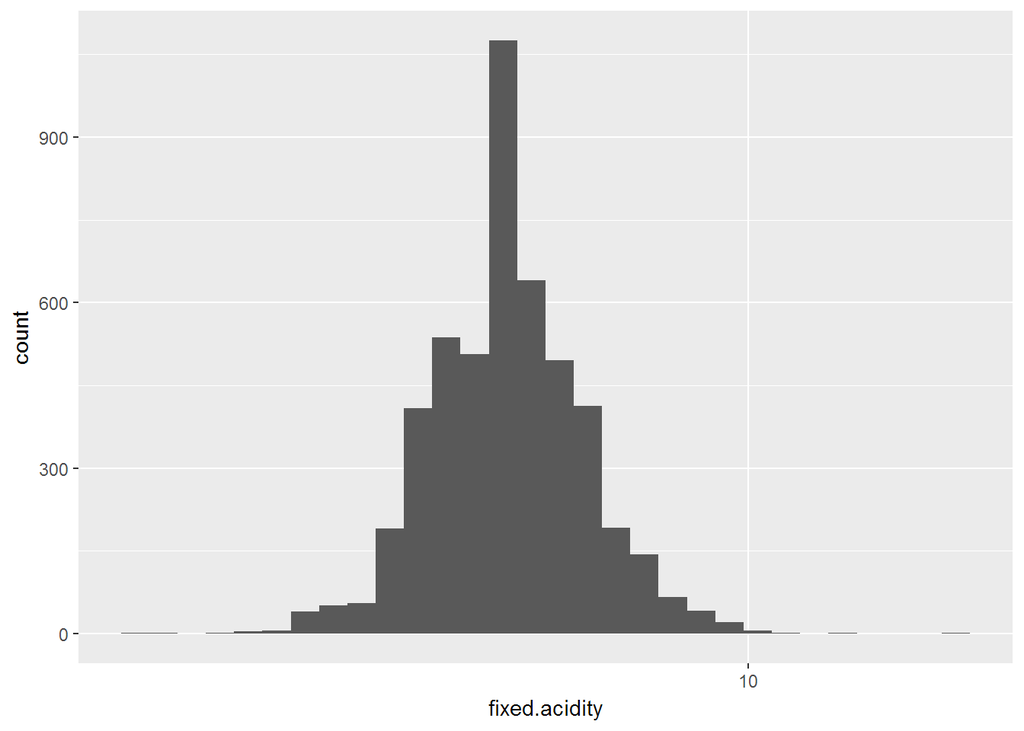

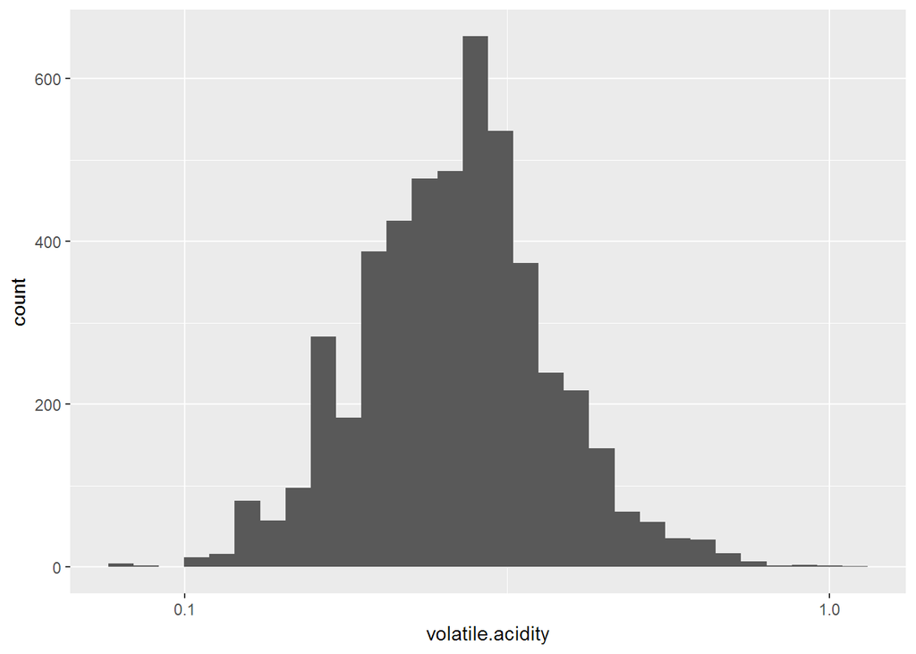

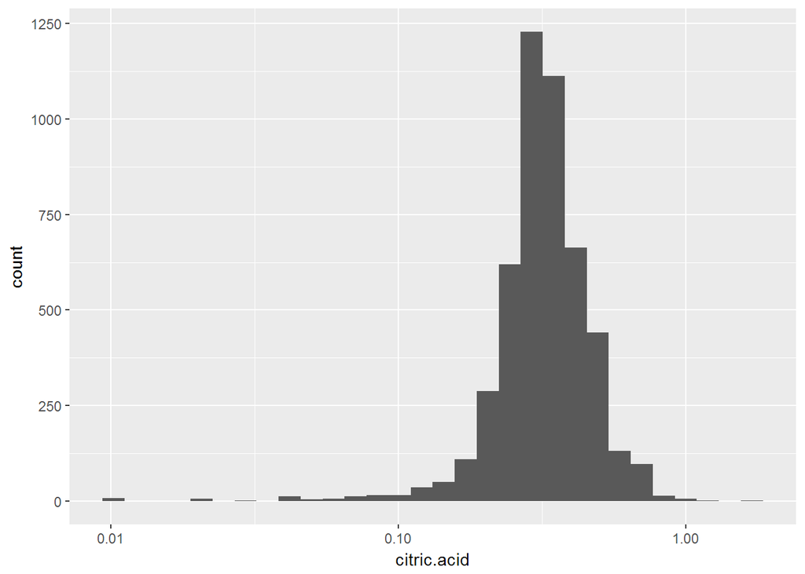

We get very normal distributions except for the tail of citric.acid, containing values lower than 0.1 g/dm^3.

### Outliers

We use boxplots with an alpha value of 0.05 to see possible outliers in each of our datasets.

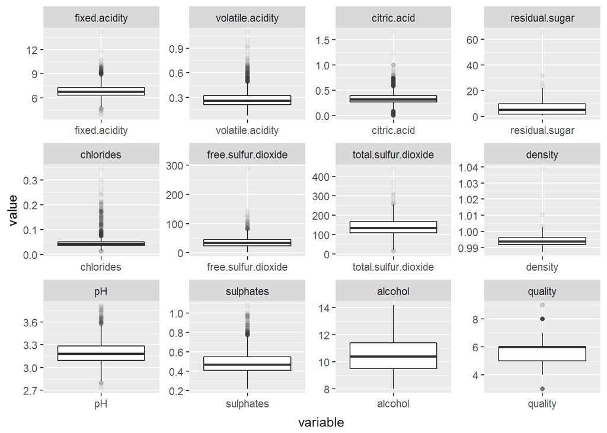

### New (Created) Features

As quality variable is basically a measure of how good or bad a wine is, it is logical to convert it to a categorical variable. For this purpose we create a new variable called “class”. We can use class to separately inspect what is happening feature-wise in different types of wine (bad, good etc.).

While separating quality levels to create a “class” variable, at first I thought using 3 classes; “bad”, “good”, and “average”. But I decided against it as bundling quality levels 5 and 6 together would cause a huge fraction of data points to be in the same class. Thus it is decided to use four levels: A, B, C and D. Grouping can be seen below:

| Quality | Class |
| --- | --- |
| 7, 8, 9, 10 | A |
| 6 | B |
| 5 | C |
| 1, 2, 3, 4 | D |

We already have a variable for pH, but when we already have 3 variables for acidity, we can assign a separate variable for acidity and use it as a feature.

Looking in the documentation, unit for all acidity variables are g/dm^3, so we can directly sum them.

# Bivariate Plots Section

To get a quick snapshot of relationships between all the fatures, we look at their plot and correlation matrices:

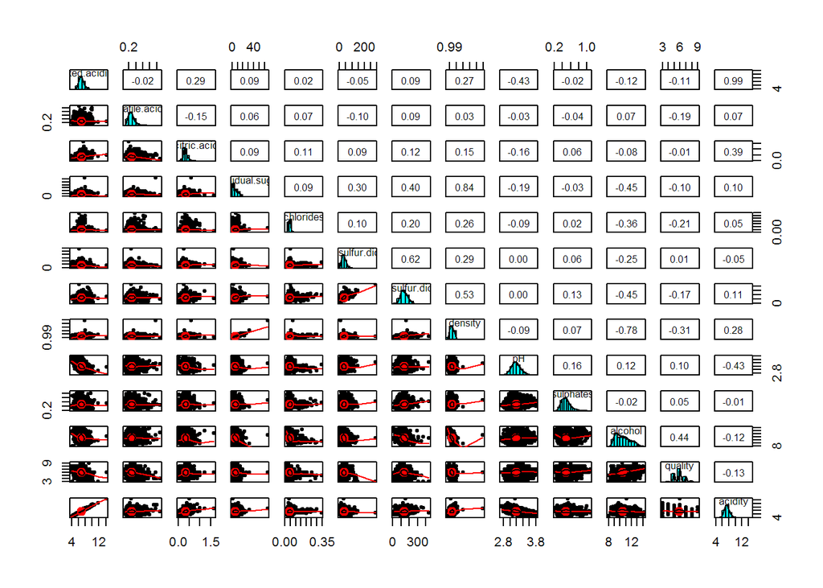

When we look at the relationship between quality and other features, there is a strong relationship between quality and alcohol. Density is correlated with alcohol (inversely) and residual sugar, which is not surprising. We also see that quality is correlated with chlorides (salt), volatile acidity, and total sulfur dioxide; all of which will be examined further.

When we use jitter and transparency on the points we see alcohol has a significant positive effect on the quality.

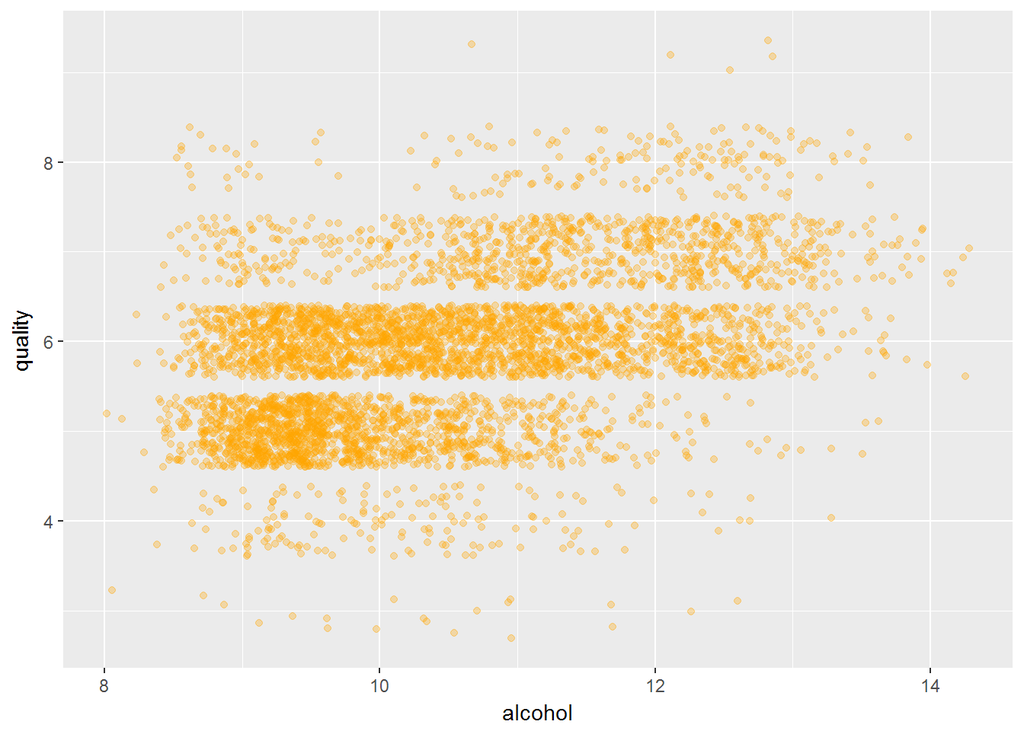

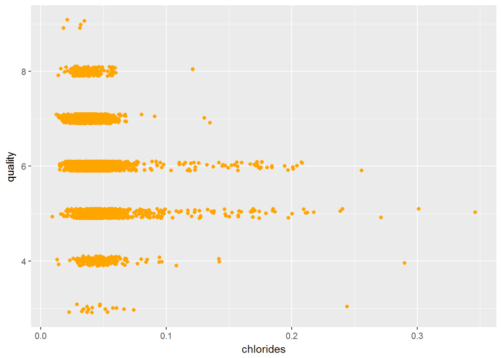

Effect of volatile acidity on quality is not exactly clear, and should be further investigated later on.

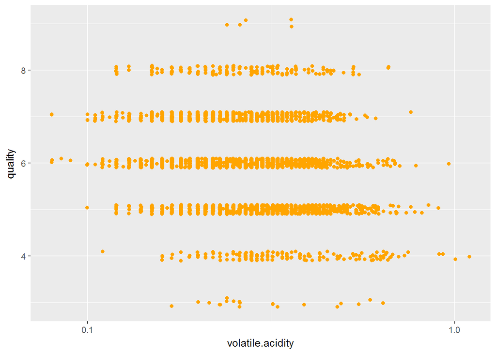

Even though we remove outliers of bottom and top by 5%, there’s no significant change on quality created by different sulfur dioxide amounts.

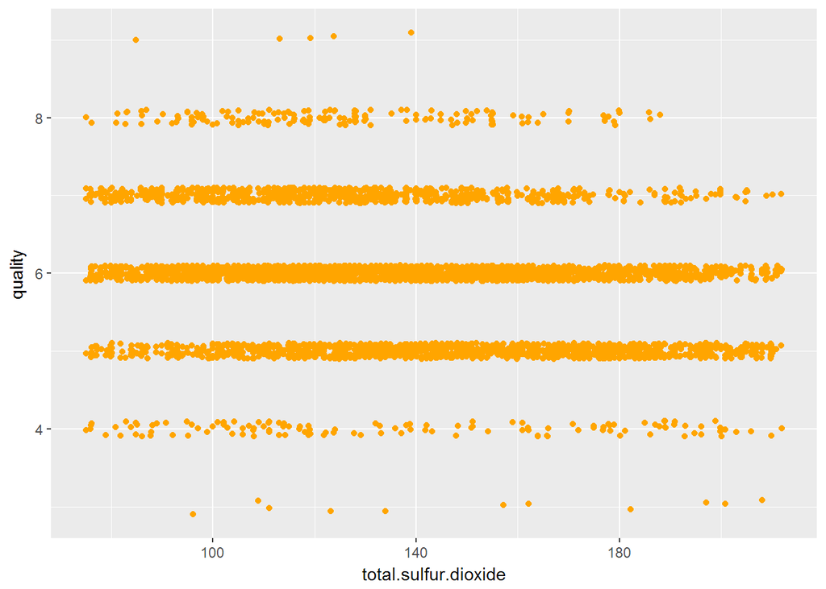

# Bivariate Analysis

Other than obvious relationships between the ones like sulfur.dioxides or acidities; strongest relationships are between density - alcohol, density - residual sugar, and quality - alcohol. It is also interesting that fixed acidity has a 0.99 correlation with acidity, suggesting fixed acids are in much higher concentrations in the wines.

# Multivariate Plots Section

we use the classes we created to differentiate points, and apply upper 95% quantile on chlorides.

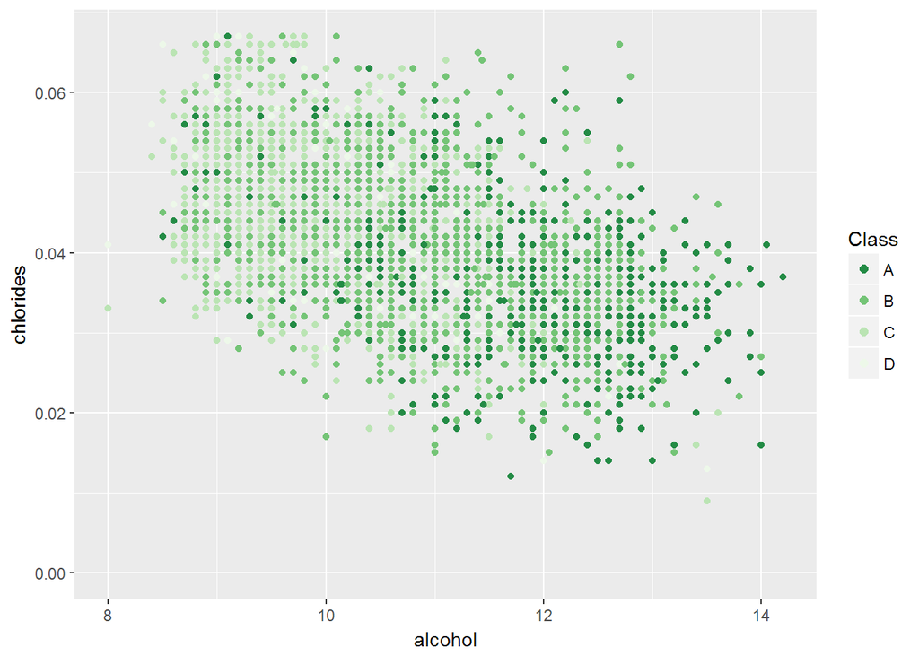

We see in the documentation that “volatile acidity” is acetic acid. If a wine has both low alcohol and high acetic acid, it tends to have worse quality.

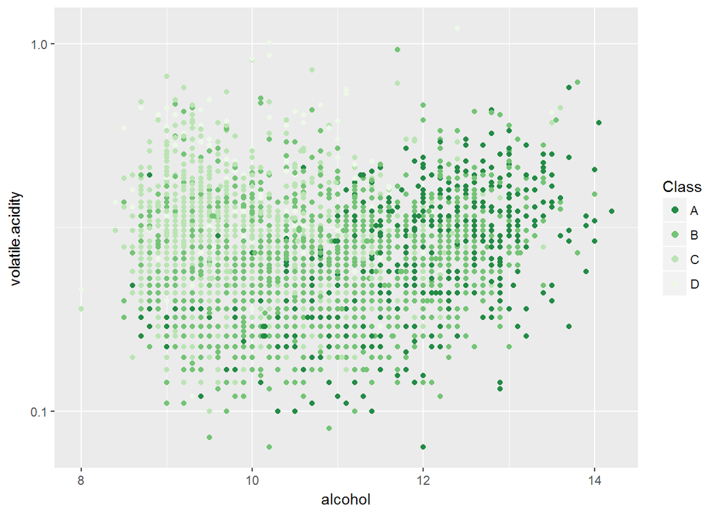

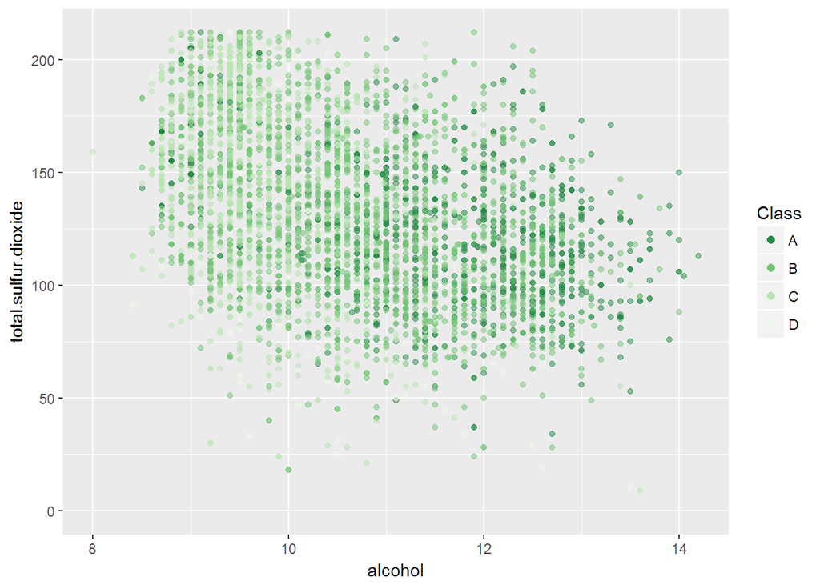

# Multivariate Analysis

### Plot One

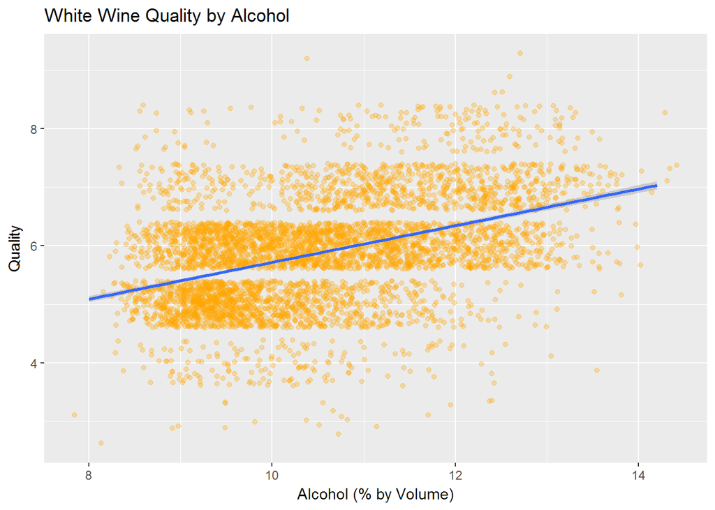

### Description One

This is the first clear indicator we have regarding the relationship between alcohol content and perceived quality of a white wine.

### Plot Two

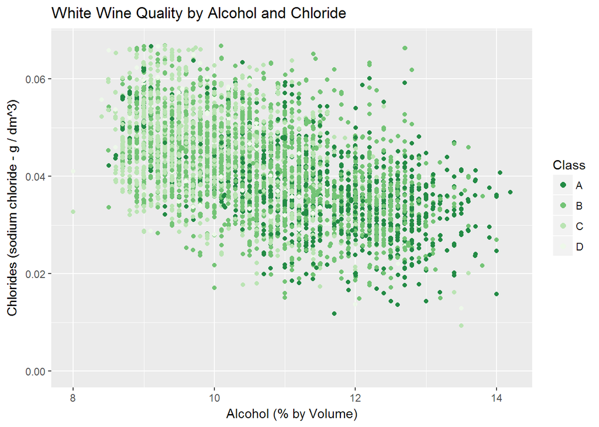

### Description Two

We see that Class A and B wines mostly reside in the lower right corner while lower quality wines are generally in upper left corner. In addition to alcohol, we see that high amount of salt might affect a wine’s quality badly.

### Plot Three

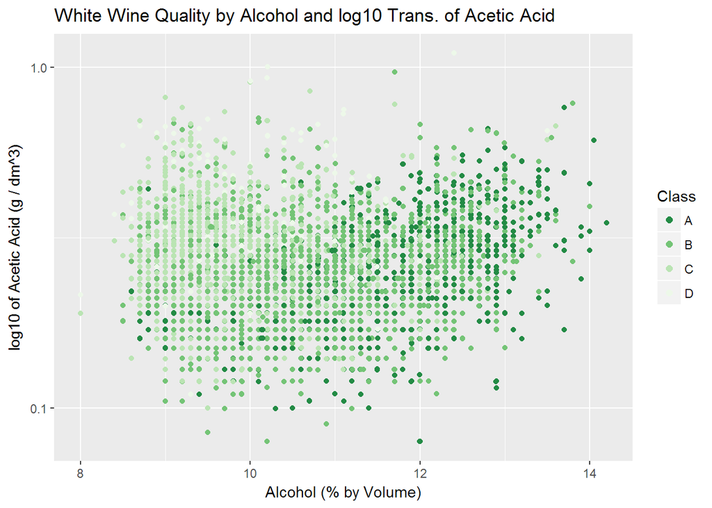

### Description Three

Finally, we also see acetic acid affecting the quality of a wine in addition to alcohol. Note the log10 transformation, used as volatile.acidity variable a form close to normal when transformed, and it is naturally a logarithmic variable.

# Reflection

Main struggle for me was having an integer variable (quality) to investigate other features’ effects on. It required more technical additions, like converting it to a ordinal variable. Also not having much of an intutition regarding which material(s) make a wine better prompted me to make extra research. Seeing how alcohol played a part in wine quality also surprised me. A point going forward could be using a mathematical model to test if the mentioned relationships are there, and can such models predict “quality” of a wine without no one testing it.